# Solutions for exercises of Section 8.

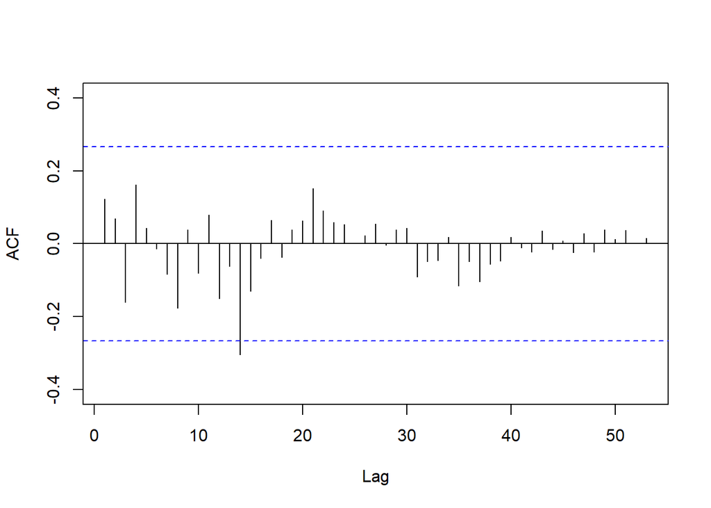

```r
Acf(diff(usnetelec), lag.max = 100, main = "")
```

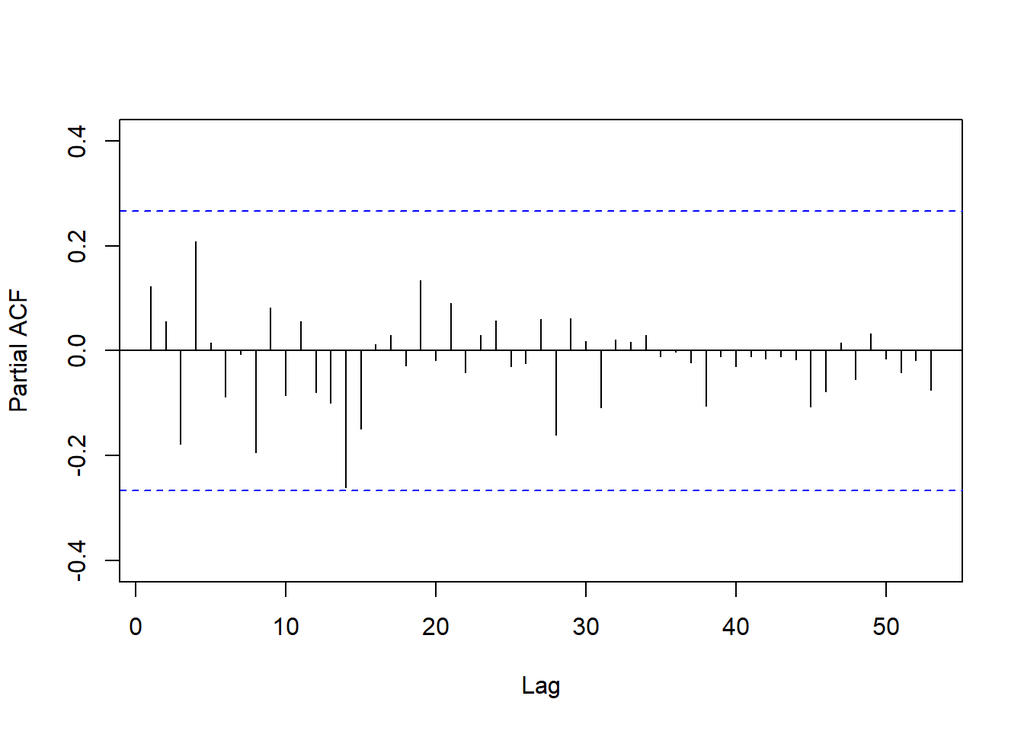

```r
Pacf(diff(usnetelec), lag.max = 100, main = "")
```

### Data set usgdp

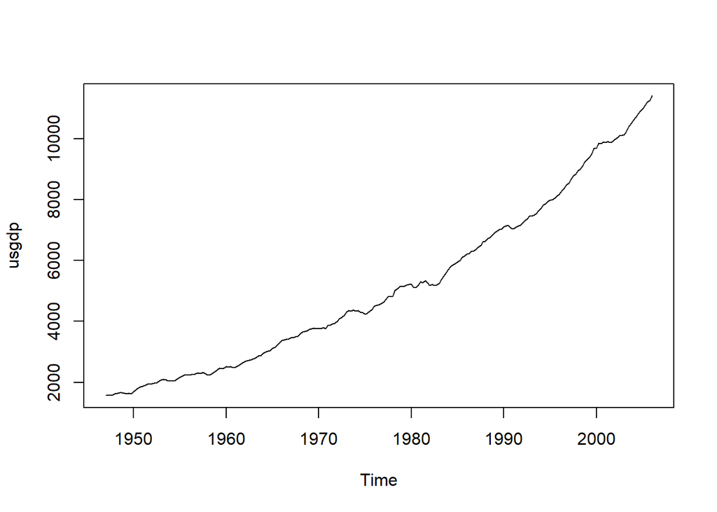

```r
plot(usgdp)
```

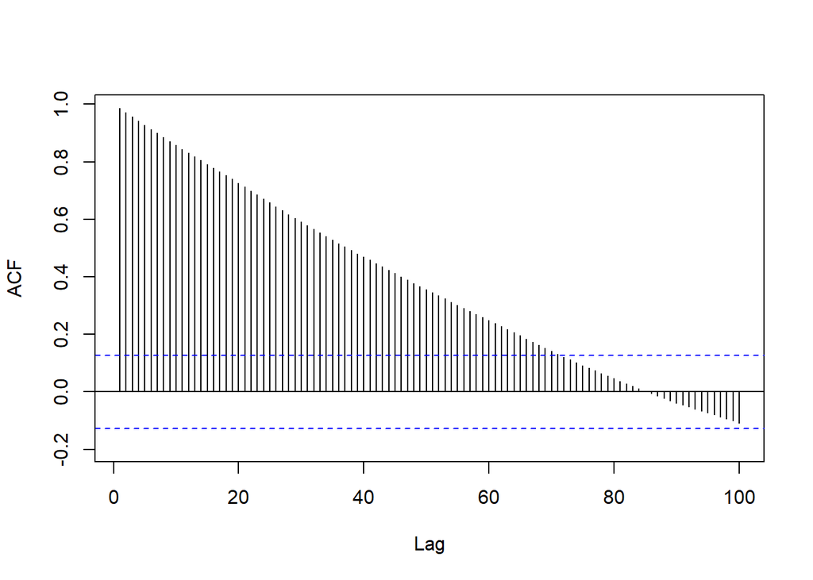

```r
Acf(usgdp, lag.max = 100, main = "")
```

ACF does not drop quickly to values inside or almost inside the critical values. Moreover the value $r_1$ is large and positive (almost 1 in this case). All this are signs of a non-stationary time series. Therefore the data should be differenced to apply ARMA model (and maybe transformed before differencing).

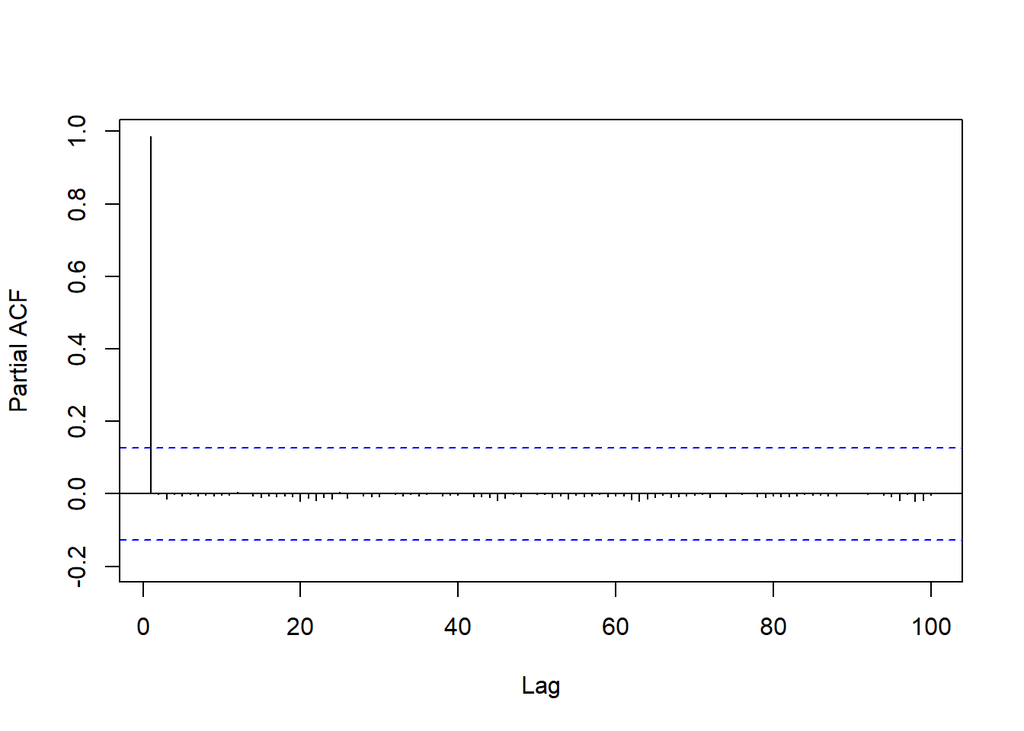

```r
Pacf(usgdp, lag.max = 100, main = "")
```

PACF value $r_1$ is almost 1. This is a sign of non-stationary process. The data should be differenced to apply ARMA model (and maybe transformed before differencing).

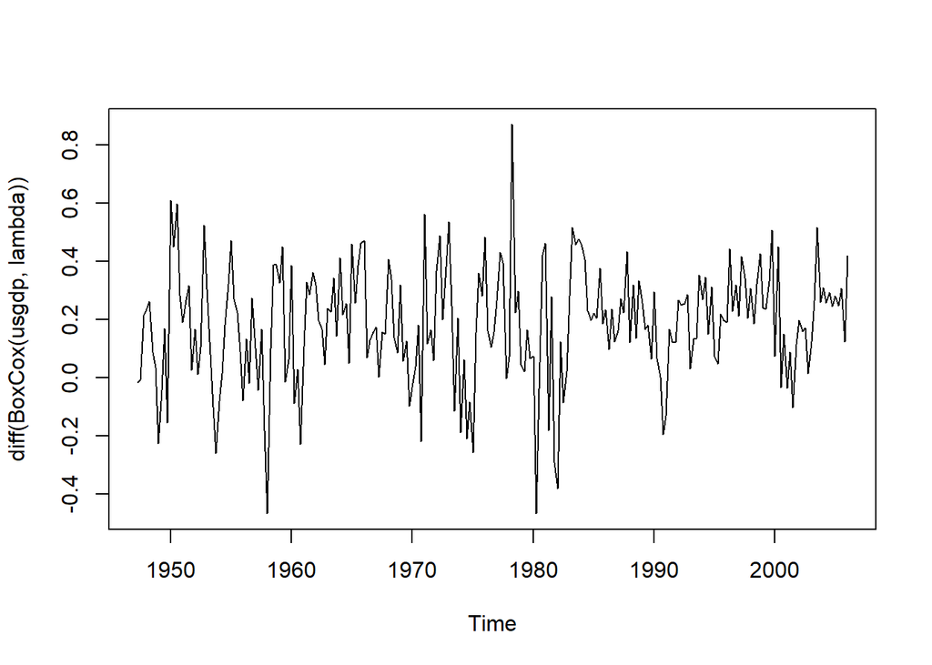

```r
lambda = BoxCox.lambda(usgdp)
plot(diff(BoxCox(usgdp, lambda)))
```

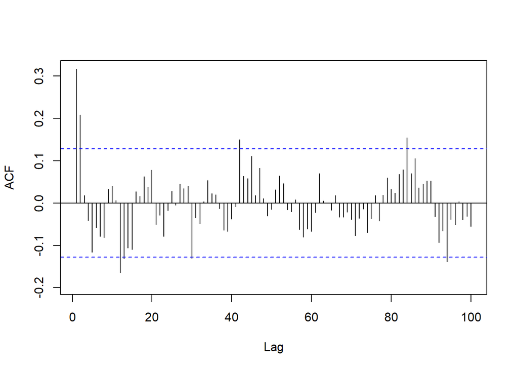

```r
Acf(diff(BoxCox(usgdp, lambda)), lag.max = 100, main = "")
```

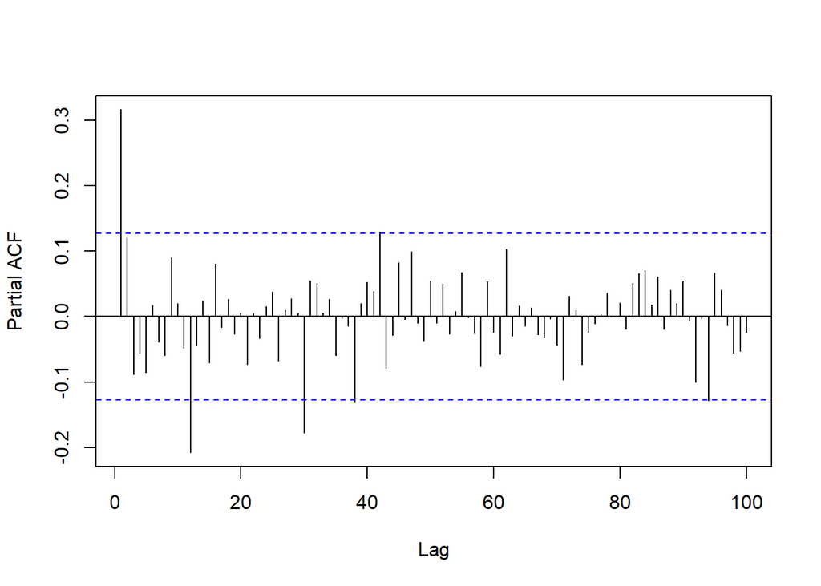

```r
Pacf(diff(BoxCox(usgdp, lambda)), lag.max = 100, main = "")
```

ACF and PACF of transformed and differenced data drops quickly with few spikes for big values of lags slightly beyond critical values. The data can be considered stationary. ARMA model can be applied.